# Grenier_Yohan_1_code_122023

[figure not shown]

### Prelude :

We have six geometric pieces of information about a banknote:

- length: the length of the banknote (mm)
- height_left: the height of the banknote (measured on the left side, mm)
- height_right: the height of the banknote (measured on the right side, mm)
- margin_up: the margin between the top edge of the banknote and its image (mm)
- margin_low: the margin between the bottom edge of the banknote and its image (mm)
- diagonal: the diagonal of the banknote (mm)

And one information about banknote:

- is_genuine: authenticity of banknotes (boolean)

The objective is : create an algorithm to detect counterfeit banknotes by **minimizing false positives** as much as possible.

## Contents

**Table of contents**

- 1. Basics
  - 1.1 Libraries
  - 1.2 Fonctions
  - 1.3 Data importation
  - 1.4 Data informations
- 2. Exploratory Analysis
  - 2.1 Univariate analysis
  - 2.2 Bivariate analysis
  - 2.3 Missing values filling
    - 2.3.1 First looking
    - 2.3.2 Looking for the best model linear regression
    - 2.3.3 Train model on selected features
    - 2.3.4 Conformity checks
      - a. Residuals values's distribution check
      - b. Residuals's homoscedasticity check
      - c. No multi collinearity check
    - 2.3.5 Estimation predicted values on NaN
    - 2.3.6 Fill missing values from multi linear regression
- 3. Two ways to find the authenticity
  - 3.1 K-means
    - 3.1.1 Clustering
    - 3.1.2 Results
    - 3.1.3 Centroids visualized on PC1 & PC2 (PCA model)
  - 3.2 Logistic regression to classify on is_genuine
    - 3.2.1 No multi collinearity check
    - 3.2.2 Looking for the best model logistic regression
    - 3.2.3 Train model on selected features
    - 3.2.4 Results
- 4. Final Supervised Classification Algorithm

## 1. Basics

### 1.1 Libraries

```python
#toolbox
import pandas as pd
import numpy as np
import matplotlib.pyplot as plt
import seaborn as sns
from math import *
import statsmodels.api as sm

#stats tools
from scipy.stats import spearmanr, mode, shapiro, probplot


#ML tools
from sklearn.linear_model import LinearRegression, LogisticRegression
from sklearn.model_selection import train_test_split,cross_validate, StratifiedKFold
from sklearn.metrics import (mean_squared_error, mean_absolute_percentage_error,
                             accuracy_score, confusion_matrix, precision_score,
                             recall_score, f1_score, roc_curve,auc)
from statsmodels.stats.diagnostic import het_breuschpagan
from sklearn.decomposition import PCA
from sklearn.preprocessing import StandardScaler
from sklearn.cluster import KMeans
from patsy import dmatrices
from statsmodels.stats.outliers_influence import variance_inflation_factor

#Remover warning messages
import warnings
warnings.filterwarnings("ignore")
```

### 1.2 Fonctions

```python
def show_shape(datasets):
    """
    datasets = {str : array, str : array}

    Show the shape of each dataset with ther name
    """
    for set in datasets:
        print("{} : {}".format(datasets[set].shape, set))
```

```python
#Editor is Openclassrooms
def correlation_graph(pca, x_y,features) :
        """Display the correlation circle graph.

        Positional arguments:
        -----------------------------------
        pca: sklearn.decomposition.PCA: our fitted PCA object
        x_y: list or tuple: the x, y pair of dimensions to display, e.g., [0, 1] for PC1, PC2
        features: list or tuple: the list of features (i.e., dimensions) to represent
        """

        # Extract x and y
        x, y = x_y

        # Image size (in inches)
        fig, ax = plt.subplots(figsize=(8, 7))

        # For each principal component:
        for i in range(0, pca.components_.shape[1]):

                # Arrows
                ax.arrow(0, 0,
                        pca.components_[x, i],
                        pca.components_[y, i],
                        head_width=0.07,
                        head_length=0.07,
                        width=0.02)

                # Labels
                plt.text(pca.components_[x, i] + 0.05,
                        pca.components_[y, i] + 0.05,
                        features[i])

        # Display horizontal and vertical lines
        plt.plot([-1, 1], [0, 0], color='grey', ls='--')
        plt.plot([0, 0], [-1, 1], color='grey', ls='--')

        # Axes labels, with the percentage of explained variance
        plt.xlabel('PC{} ({}%)'.format(x+1, round(100*pca.explained_variance_ratio_[x], 1)))
        plt.ylabel('PC{} ({}%)'.format(y+1, round(100*pca.explained_variance_ratio_[y], 1)))

        plt.title("Correlation Circle (PC{} and PC{})".format(x+1, y+1))

        # The circle
        an = np.linspace(0, 2 * np.pi, 100)
        plt.plot(np.cos(an), np.sin(an))  # Add a unit circle for scale

        # Axes and display
        plt.axis('equal')
        # plt.show(block=False)
```

```python
def show_scores(y, y_pred):
    """
    y = real values
    y_pred = predicted values
    ------
    return : confusion matrice (variable), scores(printed)

    Show performance indicators:
    - Accuracy: Accuracy is the proportion of correct predictions among the total predictions. It is a good indicator when the classes are balanced
    - Where TP is the number of true positives, TN is the number of true negatives, FP is the number of false positives, and FN is the number of false negatives
    - Precision: Precision is the proportion of positive predictions that are truly positive. It is used when the cost of false positives is high
    - Recall (or Sensitivity): Recall is the proportion of true positives that are correctly predicted as such. It is used when the cost of false negatives is high
    - F1-score: The F1-score is a harmonic mean of precision and recall. It provides a balance between these two measures
    """
    confusion_mat = confusion_matrix(y, y_pred)
    accuracy_KMeans = accuracy_score(y, y_pred)
    precision_KMeans = precision_score(y, y_pred)
    recall_KMeans = recall_score(y, y_pred)
    f1_KMeans = f1_score(y, y_pred)
    print('Confusion Matrice:\n{}'.format(confusion_mat))

    #Get values from confusion matrice
    TN, FP, FN, TP = confusion_mat.ravel()

    #Calculate rates from confusion matrice
    TPR_test = round(TP / (TP + FN) * 100, 2) #True positive rate (recall)
    FPR_test = round(FP / (FP + TN) * 100, 2) #False positive rate
    TNR_test = round(TN / (TN + FP) * 100, 2) #True negative rate (specificity)
    FNR_test = round(FN / (FN + TP) * 100, 2) #False negative rate

    # Affichage des taux pour l'ensemble de test
    print("\nTrue positive rate (recall) : {}%".format(TPR_test))
    print("False positive rate : {}%".format(FPR_test))
    print("True negative rate (specificity) : {}%".format(TNR_test))
    print("False negative rate : {}%".format(FNR_test))
    print("\n--------------\n")
    print('Accuracy: {}'.format(accuracy_KMeans))
    print('Precision: {}'.format(precision_KMeans))
    print('Recall: {}'.format(recall_KMeans))
    print('F1 Score: {}'.format(f1_KMeans))

    return confusion_mat
```

### 1.3 Data importation

```python
df_source = pd.read_csv("Ressources/billets.csv", delimiter=";")
```

```python
df_source
```

|  | is_genuine | diagonal | height_left | height_right | margin_low | margin_up | length |
| --- | --- | --- | --- | --- | --- | --- | --- |
| 0 | True | 171.81 | 104.86 | 104.95 | 4.52 | 2.89 | 112.83 |
| 1 | True | 171.46 | 103.36 | 103.66 | 3.77 | 2.99 | 113.09 |
| 2 | True | 172.69 | 104.48 | 103.50 | 4.40 | 2.94 | 113.16 |
| 3 | True | 171.36 | 103.91 | 103.94 | 3.62 | 3.01 | 113.51 |
| 4 | True | 171.73 | 104.28 | 103.46 | 4.04 | 3.48 | 112.54 |
| ... | ... | ... | ... | ... | ... | ... | ... |
| 1495 | False | 171.75 | 104.38 | 104.17 | 4.42 | 3.09 | 111.28 |
| 1496 | False | 172.19 | 104.63 | 104.44 | 5.27 | 3.37 | 110.97 |
| 1497 | False | 171.80 | 104.01 | 104.12 | 5.51 | 3.36 | 111.95 |
| 1498 | False | 172.06 | 104.28 | 104.06 | 5.17 | 3.46 | 112.25 |
| 1499 | False | 171.47 | 104.15 | 103.82 | 4.63 | 3.37 | 112.07 |

1500 rows × 7 columns

### 1.4 Data informations

```python
df_source.info()
```

```
<class 'pandas.core.frame.DataFrame'>
RangeIndex: 1500 entries, 0 to 1499
Data columns (total 7 columns):
 #   Column        Non-Null Count  Dtype
---  ------        --------------  -----
 0   is_genuine    1500 non-null   bool
 1   diagonal      1500 non-null   float64
 2   height_left   1500 non-null   float64
 3   height_right  1500 non-null   float64
 4   margin_low    1463 non-null   float64
 5   margin_up     1500 non-null   float64
 6   length        1500 non-null   float64
dtypes: bool(1), float64(6)
memory usage: 71.9 KB
```

37 missing values on **margin_low** feature.

```python
df_source.duplicated().sum()
```

```
0
```

There is no same banknote

```python
df_source.describe().round(2)
```

|  | diagonal | height_left | height_right | margin_low | margin_up | length |
| --- | --- | --- | --- | --- | --- | --- |
| count | 1500.00 | 1500.00 | 1500.00 | 1463.00 | 1500.00 | 1500.00 |
| mean | 171.96 | 104.03 | 103.92 | 4.49 | 3.15 | 112.68 |
| std | 0.31 | 0.30 | 0.33 | 0.66 | 0.23 | 0.87 |
| min | 171.04 | 103.14 | 102.82 | 2.98 | 2.27 | 109.49 |
| 25% | 171.75 | 103.82 | 103.71 | 4.01 | 2.99 | 112.03 |
| 50% | 171.96 | 104.04 | 103.92 | 4.31 | 3.14 | 112.96 |
| 75% | 172.17 | 104.23 | 104.15 | 4.87 | 3.31 | 113.34 |
| max | 173.01 | 104.88 | 104.95 | 6.90 | 3.91 | 114.44 |

## 2. Exploratory Analysis

- Univariate analysis
- Bivariate analysis
- Missing values filling

### 2.1 Univariate analysis

```
Column: diagonal | The difference between False and True : -0.08 (-0.0%)
Column: height_left | The difference between False and True : 0.23 (0.0%)
Column: height_right | The difference between False and True : 0.35 (0.0%)
Column: margin_low | The difference between False and True : 1.08 (0.26%)
Column: margin_up | The difference between False and True : 0.3 (0.1%)
Column: length | The difference between False and True : -1.58 (-0.01%)
```

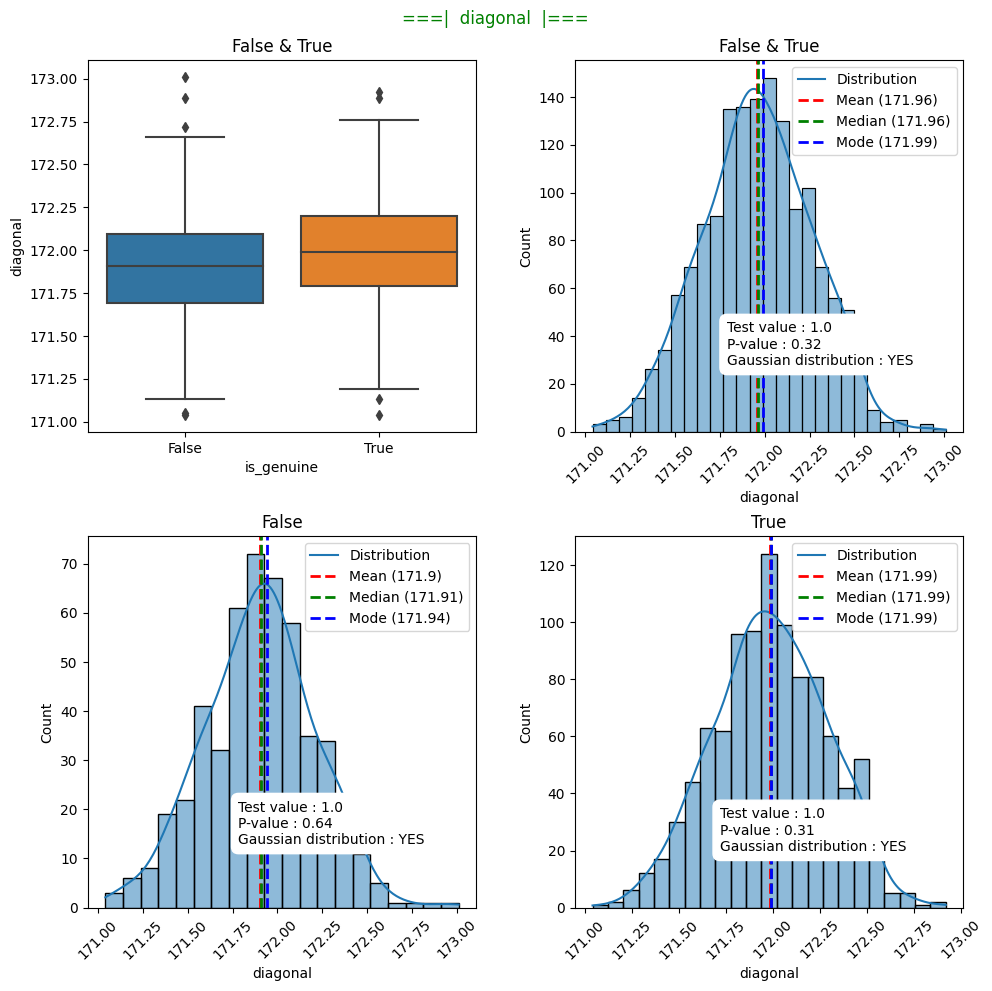

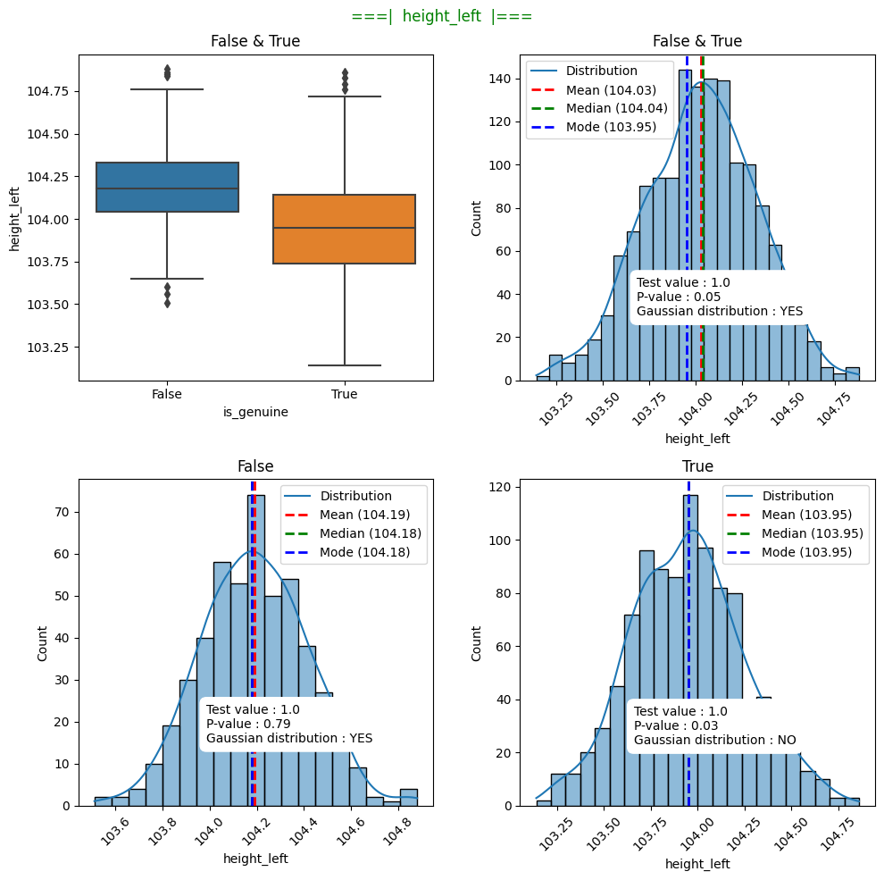

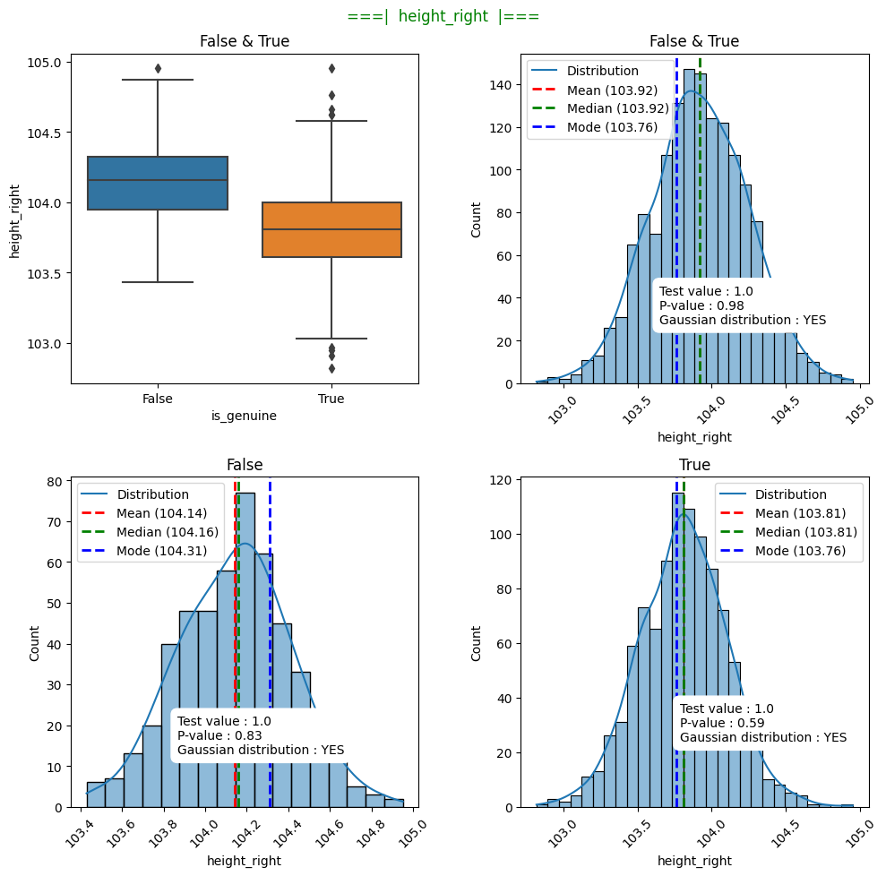

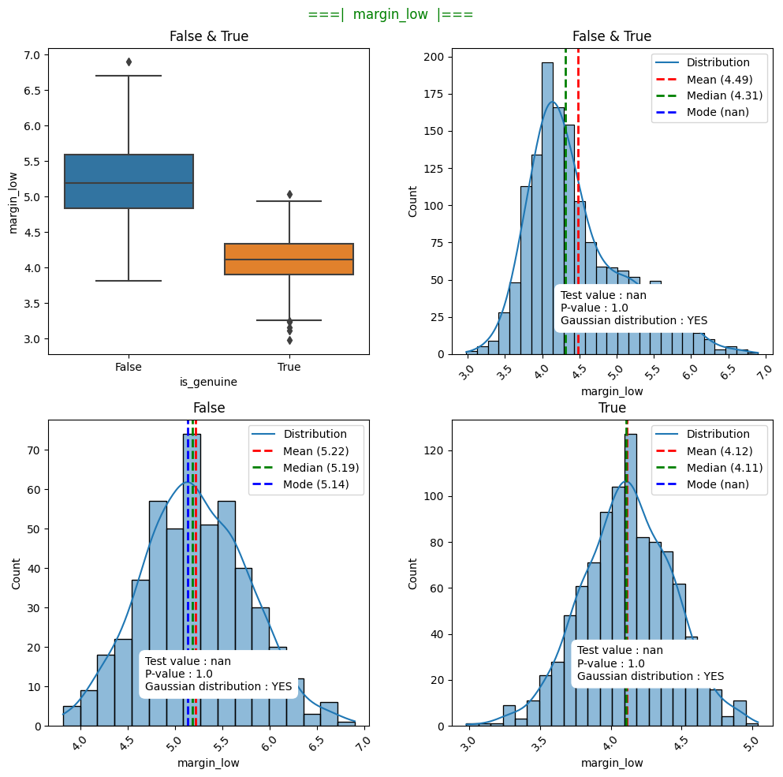

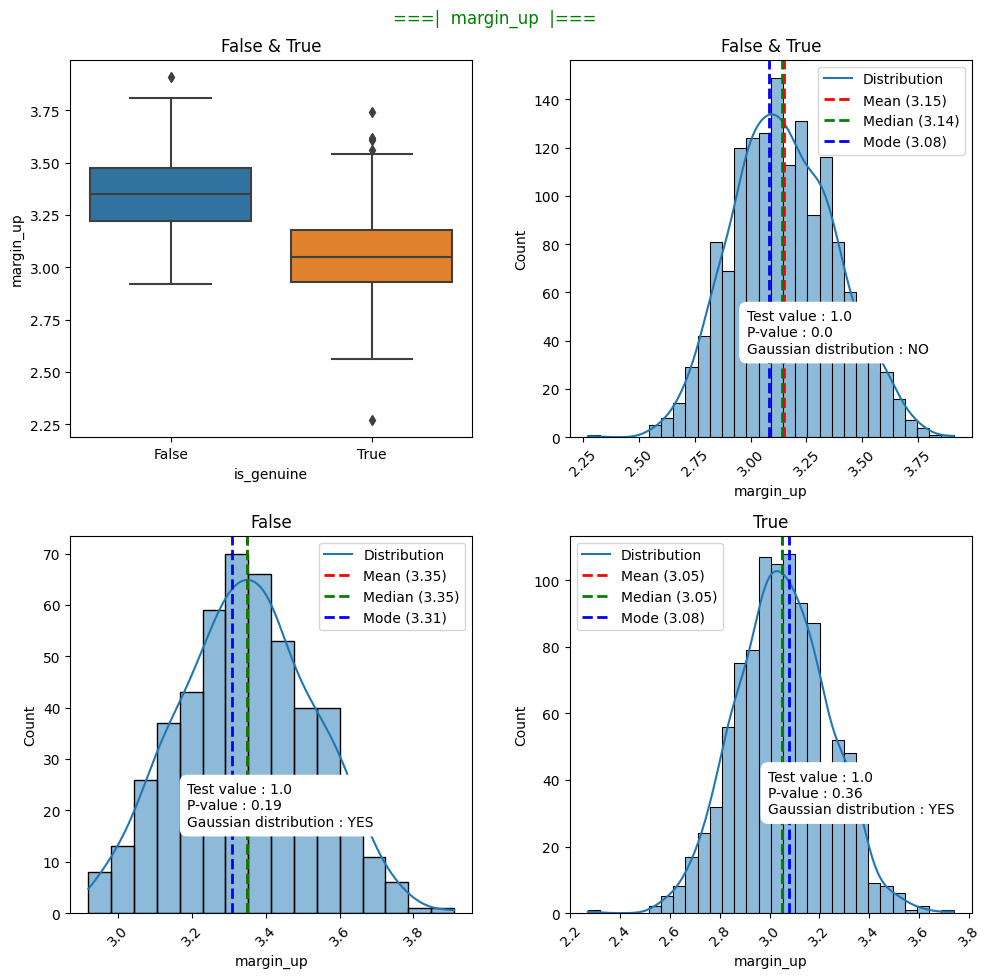

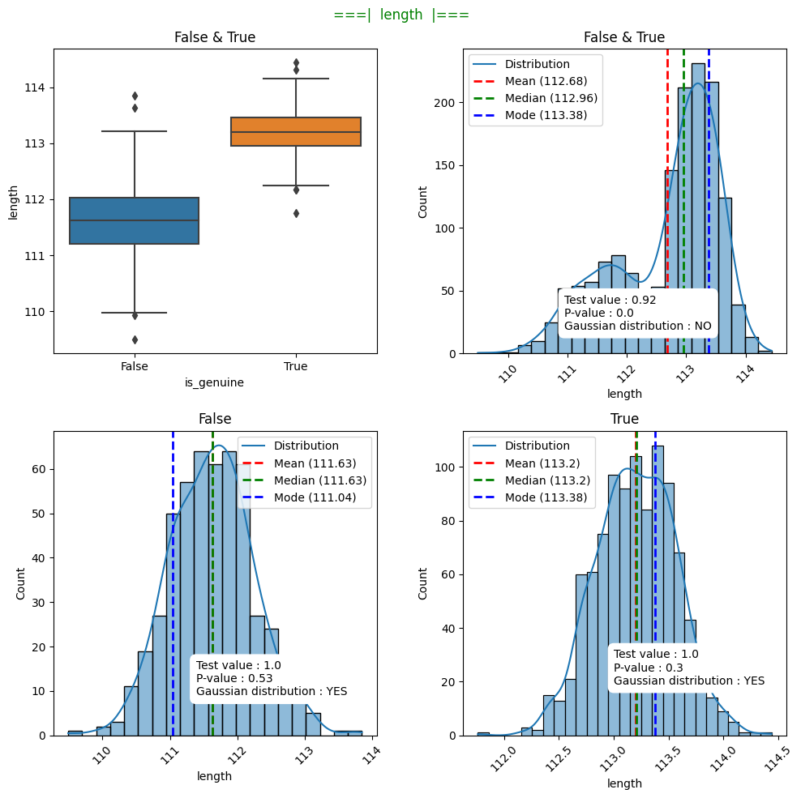

```python
for col in df_source.columns[1:]:


    plt.figure(figsize=(10,10))
    plt.suptitle("===|  {}  |===".format(col), color="Green")

    plt.subplot(221)
    plt.title("False & True")
    sns.boxplot(data=df_source, x="is_genuine", y=col);

    #------------

    plt.subplot(222)
    plt.title("False & True")
    sns.histplot(data=df_source, x=col, kde=True);
    mean = df_source[col].mean()
    med = df_source[col].median()
    mod = mode(df_source[col], axis=None, keepdims=False)[0] #scipystats object

    plt.axvline(mean, color='r', linestyle='dashed', linewidth=2, label='Mean')
    plt.axvline(med, color='g', linestyle='dashed', linewidth=2, label='Median')
    plt.axvline(mod, color='b', linestyle='dashed', linewidth=2, label='Mode')
    legend = ["Distribution",
              "Mean ({})".format(str(mean.round(2))),
              "Median ({})".format(str(med.round(2))),
              "Mode ({})".format(str(mod.round(2)))]
    plt.legend(legend)
    plt.xticks(rotation=45)

    #Compare normal distribution vs actual with Shapiro-Wilk test
    statistic, p_value = shapiro(df_source[col])

    #Return test variables
    text_x = df_source[col].max() - (df_source[col].std()*4)
    text_y = df_source[col].value_counts().max()

    #Return the result
    alpha = 0.05  #Alpha level

    if p_value > alpha:
        result = "Gaussian distribution : YES"
    else:
        result = "Gaussian distribution : NO"

    plt.text(x=text_x, y=text_y, s="Test value : {}\nP-value : {}\n{}".format(round(statistic,2), round(p_value,2), result), bbox=dict(facecolor='white', edgecolor='white', boxstyle='round,pad=0.5'))

    #------------

    df_temp = df_source.loc[df_source["is_genuine"] == 0]
    plt.subplot(223)
    plt.title("False")
    sns.histplot(data=df_temp, x=col, kde=True);
    mean = df_temp[col].mean()
    med = df_temp[col].median()
    mod = mode(df_temp[col], axis=None, keepdims=False)[0] #scipystats object

    plt.axvline(mean, color='r', linestyle='dashed', linewidth=2, label='Mean')
    plt.axvline(med, color='g', linestyle='dashed', linewidth=2, label='Median')
    plt.axvline(mod, color='b', linestyle='dashed', linewidth=2, label='Mode')
    legend = ["Distribution",
              "Mean ({})".format(str(mean.round(2))),
              "Median ({})".format(str(med.round(2))),
              "Mode ({})".format(str(mod.round(2)))]
    plt.legend(legend)
    plt.xticks(rotation=45)

    #Compare normal distribution vs actual with Shapiro-Wilk test
    statistic, p_value = shapiro(df_temp[col])

    #Return test variables
    text_x = df_temp[col].max() - (df_temp[col].std()*4)
    text_y = df_temp[col].value_counts().max()

    #Return the result
    alpha = 0.05  #Alpha level

    if p_value > alpha:
        result = "Gaussian distribution : YES"
    else:
        result = "Gaussian distribution : NO"

    plt.text(x=text_x, y=text_y, s="Test value : {}\nP-value : {}\n{}".format(round(statistic,2), round(p_value,2), result), bbox=dict(facecolor='white', edgecolor='white', boxstyle='round,pad=0.5'))

    med_false = med

    #------------

    df_temp = df_source.loc[df_source["is_genuine"] == 1]
    plt.subplot(224)
    plt.title("True")
    sns.histplot(data=df_temp, x=col, kde=True);
    mean = df_temp[col].mean()
    med = df_temp[col].median()
    mod = mode(df_temp[col], axis=None, keepdims=False)[0] #scipystats object

    plt.axvline(mean, color='r', linestyle='dashed', linewidth=2, label='Mean')
    plt.axvline(med, color='g', linestyle='dashed', linewidth=2, label='Median')
    plt.axvline(mod, color='b', linestyle='dashed', linewidth=2, label='Mode')
    legend = ["Distribution",
              "Mean ({})".format(str(mean.round(2))),
              "Median ({})".format(str(med.round(2))),
              "Mode ({})".format(str(mod.round(2)))]
    plt.legend(legend)
    plt.xticks(rotation=45)

    #Compare normal distribution vs actual with Shapiro-Wilk test
    statistic, p_value = shapiro(df_temp[col])

    ##Return test variables
    text_x = df_temp[col].max() - (df_temp[col].std()*4)
    text_y = df_temp[col].value_counts().max()

    #Return the result
    alpha = 0.05  #Alpha level

    if p_value > alpha:
        result = "Gaussian distribution : YES"
    else:
        result = "Gaussian distribution : NO"

    plt.text(x=text_x, y=text_y, s="Test value : {}\nP-value : {}\n{}".format(round(statistic,2), round(p_value,2), result), bbox=dict(facecolor='white', edgecolor='white', boxstyle='round,pad=0.5'))


    med_true = med

    #------------

    plt.tight_layout(w_pad=3)

    med_diff = round(med_false - med_true, 2)
    med_prop = round((med_false - med_true)/med_true, 2)

    print("Column: {} | The difference between False and True : {} ({}%)".format(col, med_diff, med_prop))

plt.show()
```

Focus on :

- **margin_up** & **lenght** have both :
  - common (false & true) distribution -> Gaussian distrib: **no** -> then 2 or more waves in distribution
  - **true** and **false** distributions -> Gaussian distrib: **yes** -> these variables following Gaussian distribution and can be used (possibly usefull features) AND the boxplots are showing really differents values (possibly usefull features)

### 2.2 Bivariate analysis

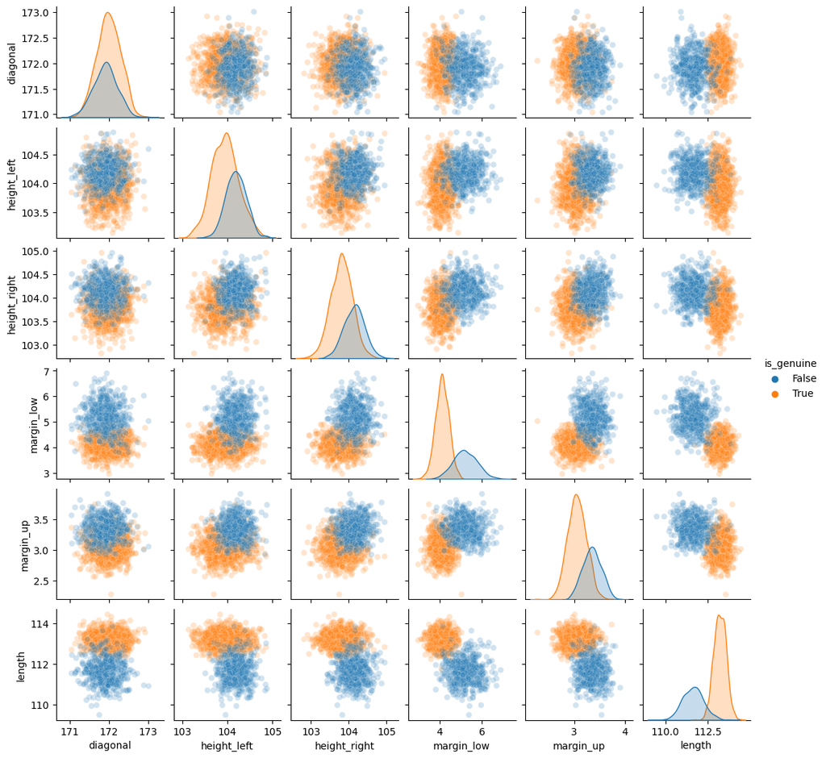

```python
sns.pairplot(data=df_source, hue="is_genuine", height=1.8, plot_kws={'alpha': 0.2}); #plot_kws to set alpha
plt.show()
```

The clusters (*True / False*) are really easy to see on the **length** feature.  
Let's check the correlation couples :

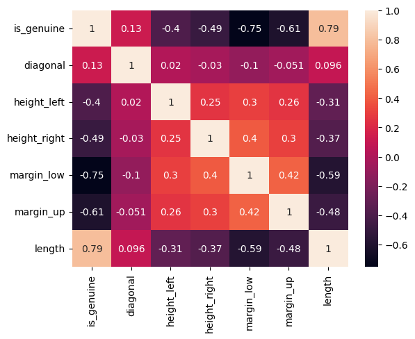

```python
#Some features are not following the Gaussian distribution, then "Spearman method" used
sns.heatmap(df_source.corr(method="spearman"), annot=True)
```

Picking interresting features to used in linear regression

### 2.3 Missing values filling

#### 2.3.1 First looking

```python
features = ['length',"margin_up", "height_right"]
target = "margin_low"
```

```python
#Check the correlation is real
for feature in features:
    statistic, p_value = spearmanr(df_source[target], df_source[feature], nan_policy="omit") #NaN are ignored

    alpha = 0.05  #alpha level

    print("Correlation test between margin_low | {}".format(feature))
    if p_value > alpha:
        result = "The result is due to the random (p_value : {} > {} (alpha))".format(round(p_value,2), alpha)
    else:
        result = "There are a significance correlation\n\np_value : {} < {} (alpha)\ncorrelation stat : {}\n-------------------".format(round(p_value,2), alpha, round(statistic,2))

    print(result)
```

```
Correlation test between margin_low | length
There are a significance correlation

p_value : 0.0 < 0.05 (alpha)
correlation stat : -0.59
-------------------
Correlation test between margin_low | margin_up
There are a significance correlation

p_value : 0.0 < 0.05 (alpha)
correlation stat : 0.42
-------------------
Correlation test between margin_low | height_right
There are a significance correlation

p_value : 0.0 < 0.05 (alpha)
correlation stat : 0.4
-------------------
```

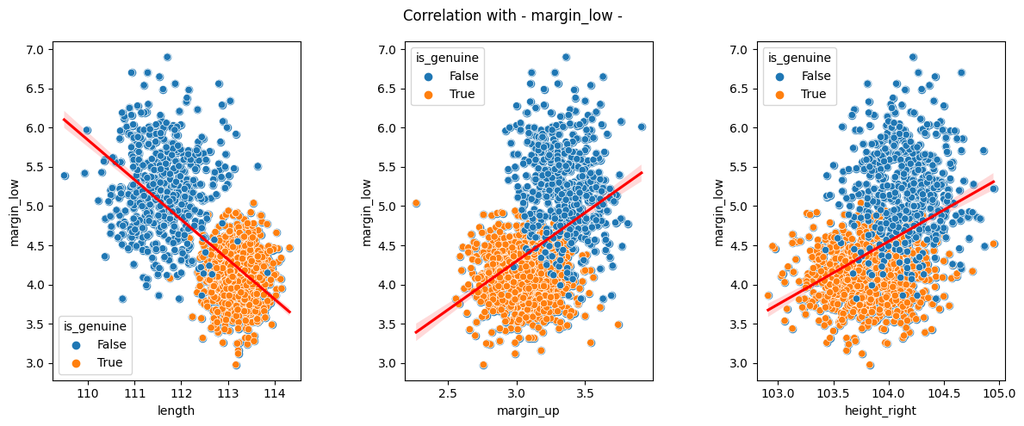

```python
#Correlation visualize
num_subplot = (len(features)*10) + 101
plt.figure(figsize=(12,5))
plt.suptitle("Correlation with - margin_low -")
for feature in features:
    plt.subplot(num_subplot)
    sns.regplot(data=df_source, x=feature, y=target, line_kws={"color": "red"})
    sns.scatterplot(data=df_source, x=feature, y=target, hue="is_genuine")
    num_subplot += 1
plt.tight_layout(w_pad=5)
plt.show()
```

#### 2.3.2 Looking for the best model linear regression

```python
#Split missing values and not NaN
df_full_values = df_source.loc[df_source["margin_low"].notna()]
print(df_full_values.shape)


df_to_impute = df_source.loc[df_source["margin_low"].isna()]
print(df_to_impute.shape)
```

```
(1463, 7)
(37, 7)
```

```python
df_full_values["margin_up_squared"] = df_full_values["margin_up"]**2
```

```python
#Define different features to test with the model
models = {"margin_low ~ length":["length"],
         "margin_low ~ length + margin_up":["length", "margin_up"],
         "margin_low ~ length + margin_up_squared":["length", "margin_up_squared"],
         "margin_low ~ length + margin_up + height_right":["length", "margin_up", "height_right"]}
```

```python
#Compare the different model scores

for model in models:
    features = models[model]


    #Feedback for information
    print("==================\n{}\n------------------".format(model))

    #Define features (X) and target (y)
    X = df_full_values[features]
    y = df_full_values[target]

    #margin_up_squarred feature have high values -> normalize
    norm_model = StandardScaler()
    X_scaled = norm_model.fit_transform(X)
    X_scaled = pd.DataFrame(X_scaled)
    X_scaled.columns = features

    #Split train & test dataset
    X_train, X_test, y_train, y_test = train_test_split(X_scaled, y, test_size=0.2, random_state=18, stratify=df_full_values["is_genuine"])

    datasets = {"X_train":X_train, "X_test":X_test, "y_train":y_train, "y_test":y_test}

    for set in datasets:
        print("{} : {}".format(datasets[set].shape, set))

    #Model init
    model = LinearRegression()

    #Fitting model on data
    model.fit(X_train, y_train);

    #Get the predicted values
    y_pred_test = model.predict(X_test)

    #Check the differences between real and predicted values
    rmse_score = round(mean_squared_error(y_test, y_pred_test),3)
    mape_score = round(mean_absolute_percentage_error(y_test, y_pred_test),3)

    print("------------------\nRMSE: {}".format(rmse_score))
    print("MAPE: {}".format(mape_score))

    #Score R**2
    print("R2 = {}".format(round(model.score(X_scaled, y),2)))

    #Coefficients show
    coefficients = []
    for i, feature in enumerate(features):
        #a*x text
        coef_text = "{} * {}".format(str(model.coef_[i].round(2)), feature)
        coefficients.append(coef_text)

    #Linear regression math formula: f(x) = a1*x + a2*x [..] + an*x + b
    a = " + ".join(coefficients)
    b = model.intercept_.round(2)

    print("f(x) = {} + {}\n==================\n-------------".format(a, b))
```

```
==================
margin_low ~ length
------------------
(1170, 1) : X_train
(293, 1) : X_test
(1170,) : y_train
(293,) : y_test
------------------
RMSE: 0.24
MAPE: 0.088
R2 = 0.44
f(x) = -0.45 * length + 4.49
==================
-------------
==================
margin_low ~ length + margin_up
------------------
(1170, 2) : X_train
(293, 2) : X_test
(1170,) : y_train
(293,) : y_test
------------------
RMSE: 0.241
MAPE: 0.087
R2 = 0.45
f(x) = -0.4 * length + 0.08 * margin_up + 4.49
==================
-------------
==================
margin_low ~ length + margin_up_squared
------------------
(1170, 2) : X_train
(293, 2) : X_test
(1170,) : y_train
(293,) : y_test
------------------
RMSE: 0.241
MAPE: 0.087
R2 = 0.45
f(x) = -0.4 * length + 0.09 * margin_up_squared + 4.49
==================
-------------
==================
margin_low ~ length + margin_up + height_right
------------------
(1170, 3) : X_train
(293, 3) : X_test
(1170,) : y_train
(293,) : y_test
------------------
RMSE: 0.228
MAPE: 0.084
R2 = 0.47
f(x) = -0.38 * length + 0.07 * margin_up + 0.08 * height_right + 4.49
==================
-------------
```

**margin_low ~ length + margin_up + height_right** seems to be the most effective :

- Lowest RMSE score
- MAPE score close to 0
- Hightest R2 score

#### 2.3.3 Train model on selected features

```python
#Features pick from the last test
features = ["length", "margin_up", "height_right"]
```

```python
#Feedback for information
print("Feature : {}".format(features))
print("Target feature : {}".format(target))
```

```
Feature : ['length', 'margin_up', 'height_right']
Target feature : margin_low
```

```python
#Define features (X) and target (y)
X = df_full_values[features]
y = df_full_values[target]
```

```python
#Split train & test dataset
X_train, X_test, y_train, y_test = train_test_split(X, y, test_size=0.2, random_state=18, stratify=df_full_values["is_genuine"])
```

```python
datasets = {"X_train":X_train, "X_test":X_test, "y_train":y_train, "y_test":y_test}

show_shape(datasets)
```

```
(1170, 3) : X_train
(293, 3) : X_test
(1170,) : y_train
(293,) : y_test
```

```python
#Model init
model = LinearRegression()

#Fitting model on data
model.fit(X_train, y_train);

#Get the predicted values
y_pred_test = model.predict(X_test)
```

```python
#Check the differences between real and predicted values
rmse_score = round(mean_squared_error(y_test, y_pred_test),3)
mape_score = round(mean_absolute_percentage_error(y_test, y_pred_test),3)

print("RMSE: {}".format(rmse_score))
print("MAPE: {}".format(mape_score))
```

```
RMSE: 0.228
MAPE: 0.084
```

Use the RMSE score to compare with other model (features pick)  
MAPE score is close to 0 -> the model performs

```python
#Score R**2
print("R2 = {}".format(round(model.score(X, y),2)))

#Coefficients show
coefficients = []
for i, feature in enumerate(features):
    #a*x text
    coef_text = "{} * {}".format(str(model.coef_[i].round(2)), feature)
    coefficients.append(coef_text)

#Linear regression math formula: f(x) = a1*x + a2*x [..] + an*x + b
a = " + ".join(coefficients)
b = model.intercept_.round(2)

print("f(x) = {} + {}".format(a, b))
```

```
R2 = 0.47
f(x) = -0.43 * length + 0.32 * margin_up + 0.24 * height_right + 27.59
```

R2 should be highter than 0.5 (close to 1) to be representative  
We can't have a better score

```python
#Get residuals values
residuals =  y_test - y_pred_test
```

#### 2.3.4 Conformity checks

##### a. Residuals values's distribution check

```python
#Shapiro test
statistic, p_value = shapiro(residuals)

alpha = 0.05  #alpha level

if p_value > alpha:
    print("The residuals values's distribution is following a Gaussian curve\np-value : {}".format(round(p_value,2)))
else:
    print("The residuals values's distribution is NOT following a Gaussian curve\np-value : {}".format(round(p_value,2)))
```

```
The residuals values's distribution is NOT following a Gaussian curve
p-value : 0.04
```

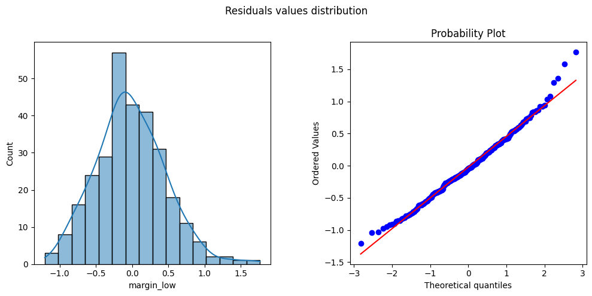

```python
#Visual check
plt.figure(figsize=(10,5))
plt.suptitle("Residuals values distribution")

plt.subplot(121)
sns.histplot(residuals, kde=True);

plt.subplot(122)
probplot(residuals, plot=plt)

plt.tight_layout(w_pad=5)
plt.show()
```

The test show not Gaussian distribution followed (0.04 close to 0.05), but the graphs are enought

##### b. Residuals's homoscedasticity check

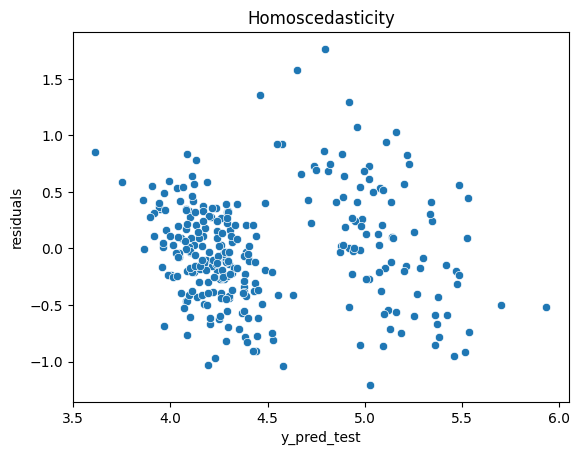

```python
plt.title("Homoscedasticity")
sns.scatterplot(x=y_pred_test, y=residuals)
plt.ylabel("residuals")
plt.xlabel("y_pred_test")
```

No specific pattern (line, W, V, S curve, etc...) -> Homoscedasticity OK

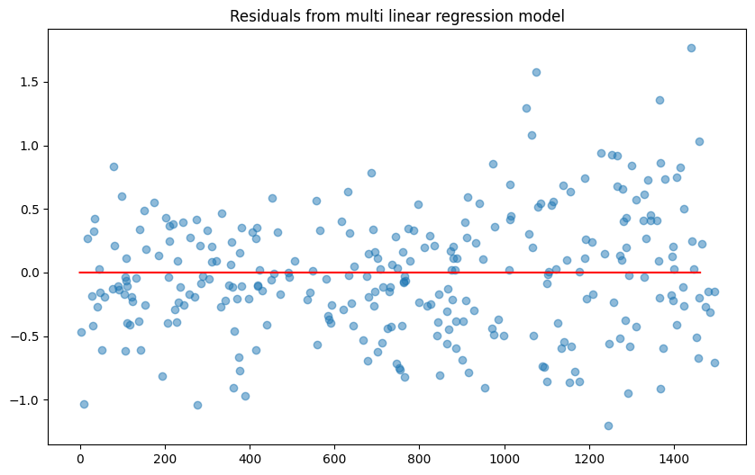

```python
#Residuals show on one axis
plt.subplots(figsize=(10, 6))
plt.scatter(x=X_test.index, y=residuals, alpha=0.5)
plt.plot(np.repeat(0, len(X.index)), color='red')
plt.title('Residuals from multi linear regression model')
plt.show()
```

```python
#Add constant feature to the matrice with explanatory features
X_constant = sm.add_constant(X_test)

#Breusch-Pagan test
_, pval, _, _ = het_breuschpagan(residuals, X_constant)

# Afficher la p-value
print("P-value : {}".format(pval))
```

```
P-value : 0.0012222296083232555
```

Heteroskedasticity is present due from the test.  
But this test is really harsh.

The tests don't confirm our hypothesis, but the results on graphs are enougth to use this model to fill NaN.

##### c. No multi collinearity check

```python
#Get correlation matrice with intercept (1) column added
_, X_vif = dmatrices('margin_low~length+margin_up+height_right', data=df_source, return_type='dataframe')

#Calculate VIF
vif = pd.DataFrame()
vif['VIF'] = [variance_inflation_factor(X_vif.values, i) for i in range(X_vif.shape[1])]
vif['variable'] = X_vif.columns
vif[1:]
```

|  | VIF | variable |
| --- | --- | --- |
| 1 | 1.509435 | length |
| 2 | 1.394010 | margin_up |
| 3 | 1.213794 | height_right |

The VIF (Variance Inflation Factor) should be under 5 to prouve the no multi collinearity -> it's OK

#### 2.3.5 Estimation predicted values on NaN

Let's visualize the predicted values on NaN

```python
#Predict missing values to visualize
x_missing_values = df_to_impute[features].iloc[:,0]
y_missing_values_pred = model.predict(df_to_impute[features]).tolist()
```

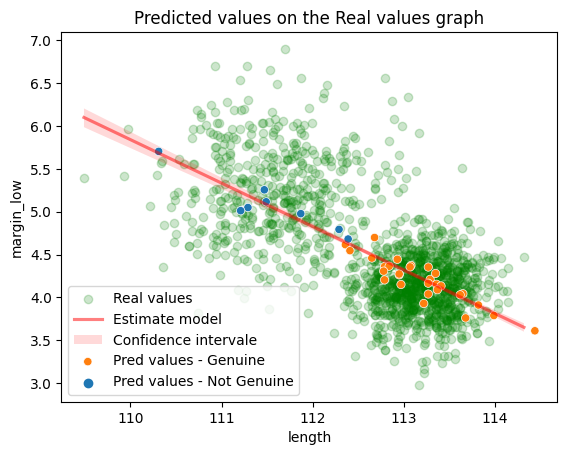

```python
plt.title("Predicted values on the Real values graph")

sns.regplot(x=X.iloc[:,0], y=y.tolist(), color="g", scatter_kws={"alpha": 0.2}, line_kws={"color": "red", "alpha":0.5})
sns.scatterplot(x=x_missing_values, y=y_missing_values_pred, hue=df_to_impute["is_genuine"])
plt.ylabel("margin_low")
plt.xlabel("length")
plt.legend(["Real values", "Estimate model", "Confidence intervale", "Pred values - Genuine", "Pred values - Not Genuine"])

plt.show()
```

#### 2.3.6 Fill missing values from multi linear regression

```python
df_refill = df_source.copy()

df_refill.loc[df_refill["margin_low"].isna(), ["margin_low"]] = model.predict(df_refill.loc[df_refill["margin_low"].isna(),features])
```

```python
df_refill.info()
```

```
<class 'pandas.core.frame.DataFrame'>
RangeIndex: 1500 entries, 0 to 1499
Data columns (total 7 columns):
 #   Column        Non-Null Count  Dtype
---  ------        --------------  -----
 0   is_genuine    1500 non-null   bool
 1   diagonal      1500 non-null   float64
 2   height_left   1500 non-null   float64
 3   height_right  1500 non-null   float64
 4   margin_low    1500 non-null   float64
 5   margin_up     1500 non-null   float64
 6   length        1500 non-null   float64
dtypes: bool(1), float64(6)
memory usage: 71.9 KB
```

## 3. Two ways to find the authenticity

- K-means
- Logistic regression

### 3.1 K-means

#### 3.1.1 Clustering

```python
#Define features and target
features = ['diagonal', 'height_left', 'height_right',
            'margin_low', 'margin_up', 'length']
target = 'is_genuine'

#Get information in X and y
X = df_refill[features]
y = df_refill[target]
```

```python
#Scaled data is a mandatory for this model
model_normalizer = StandardScaler()

#Fitting model on datas
model_normalizer.fit(X)

#Scaling
X_scaled = model_normalizer.transform(X)

datasets = {"X_scaled":X_scaled}
show_shape(datasets)
```

```
(1500, 6) : X_scaled
```

```python
#Model init
model_kmeans = KMeans(n_clusters=2, n_init=5, random_state=18)

#Fitting model on datas
model_kmeans.fit(X_scaled)

#Get x predicted (f(x))
y_pred_kmeans = model_kmeans.predict(X_scaled)

#Get centroids
centroids = model_kmeans.cluster_centers_

#Get clusters
clusters = model_kmeans.labels_
```

#### 3.1.2 Results

```python
#Get confusion matrice and scores
confusion_matrice = show_scores(y, y_pred_kmeans)
```

```
Confusion Matrice:
[[486  14]
 [ 10 990]]

True positive rate (recall) : 99.0%
False positive rate : 2.8%
True negative rate (specificity) : 97.2%
False negative rate : 1.0%

--------------

Accuracy: 0.984
Precision: 0.9860557768924303
Recall: 0.99
F1 Score: 0.9880239520958083
```

Other performance indicators:

- Accuracy: Accuracy is the proportion of correct predictions among the total predictions. It is a good indicator when the classes are balanced | (00 + 11) / (00+01+10+11)
- Where TP is the number of true positives, TN is the number of true negatives, FP is the number of false positives, and FN is the number of false negatives | TP:11 - TN:00 - FP:01 - FN:10
- Precision: Precision is the proportion of positive predictions that are truly positive. It is used when the cost of false positives is high | 11/(11+01) | TP/(TP+FP)
- Recall (or Sensitivity): Recall is the proportion of true positives that are correctly predicted as such. It is used when the cost of false negatives is high | 11/(11+10) | TP/(TP+FN)
- F1-score: The F1-score is a harmonic mean of precision and recall. It provides a balance between these two measures | (2 x Precision x Recall) / (Precision + Recall)

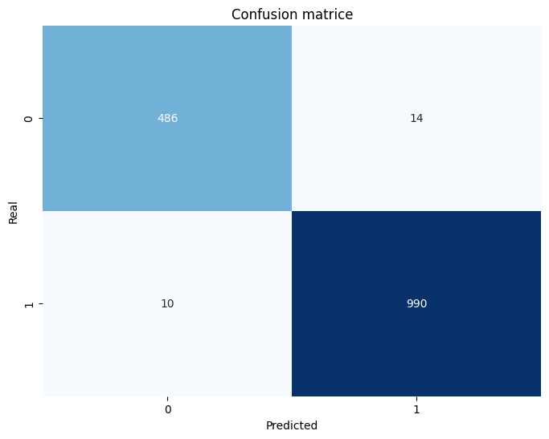

```python
plt.figure(figsize=(8, 6))
plt.title('Confusion matrice')
sns.heatmap(confusion_matrice, annot=True, fmt='d', cmap='Blues', cbar=False)
plt.xlabel('Predicted')
plt.ylabel('Real')

plt.show()
```

#### 3.1.3 Centroids visualized on PC1 & PC2 (PCA model)

```python
#init model
model_PCA = PCA()

#Fitting on datas
model_PCA.fit(X_scaled)

#PCs creation
X_pca = model_PCA.transform(X_scaled)
centroids_pca = model_PCA.transform(centroids)

model_PCA.explained_variance_ratio_.round(2).cumsum()
```

```
array([0.43, 0.6 , 0.73, 0.85, 0.95, 1.  ])
```

60% variances are explained on the 2 firsts principal components

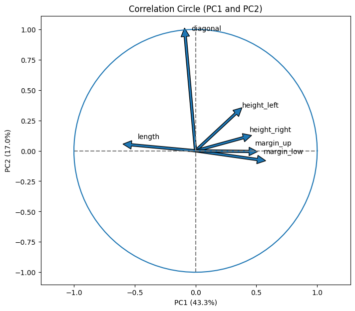

```python
correlation_graph(model_PCA, [0,1], features)
```

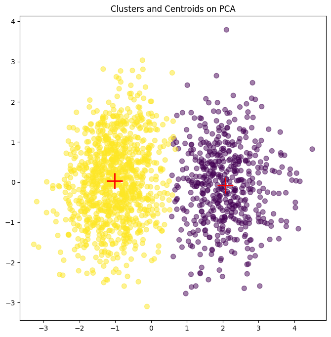

```python
plt.figure(figsize=(8,8))
plt.title('Clusters and Centroids on PCA')

plt.scatter(X_pca[:, 0], X_pca[:, 1],c=y_pred_kmeans, s=50, alpha=0.5)
plt.scatter(centroids_pca[:, 0], centroids_pca[:, 1], c='red', marker='+', s=500, linewidth=2)

plt.show()
```

To conclude :  
Kmeans seems easy and good way to classify but this model is not perfect.  
We should try with logistic regression.

### 3.2 Logistic regression to classify on is_genuine

#### 3.2.1 No multi collinearity check

```python
#Show columns name to easy copy/paste
df_refill.columns
```

```
Index(['is_genuine', 'diagonal', 'height_left', 'height_right', 'margin_low',
       'margin_up', 'length'],
      dtype='object')
```

```python
#Get correlation matrice with intercept (1) column added
_, X_vif = dmatrices('margin_low~diagonal+height_left+height_right+margin_up+length', data=df_refill, return_type='dataframe')

#Calculate VIF
vif = pd.DataFrame()
vif['VIF'] = [variance_inflation_factor(X_vif.values, i) for i in range(X_vif.shape[1])]
vif['variable'] = X_vif.columns
vif[1:]
```

|  | VIF | variable |
| --- | --- | --- |
| 1 | 1.012790 | diagonal |
| 2 | 1.145295 | height_left |
| 3 | 1.229263 | height_right |
| 4 | 1.403517 | margin_up |
| 5 | 1.574765 | length |

The VIF should to be under 5 to prouve the no multi collinearity -> it's OK

#### 3.2.2 Looking for the best model logistic regression

```python
#Define different features to test with the model
models = {"is_genuine ~ length":["length"],
         "is_genuine ~ length + margin_low":["length", "margin_low"],
         "is_genuine ~ length + margin_low + margin_up":["length", "margin_low", "margin_up"],
         "is_genuine ~ length + margin_low + height_right":["length", "margin_low", "height_right"],
         "is_genuine ~ length + margin_low + margin_up + height_right":["length", "margin_low", "margin_up", "height_right"],
         "is_genuine ~ ALL (length + margin_low + margin_up + height_right + height_left + diagonal)":["length", "margin_low", "margin_up", "height_right", "height_left", "diagonal"]}
```

Test with kfold cross validation (stratify on target feature)

```python
for model in models:
    #Define features and target
    features = models[model]
    target = 'is_genuine'

    #Define numbers of folds
    k = 8

    #Feedback for information
    print("==================\n{}\n------------------\nMean on {} folds".format(model, k))

    #Get information in X and y
    X = df_refill[features]
    y = df_refill[target]

    #Normalize data
    norm_model = StandardScaler()
    X_scaled = norm_model.fit_transform(X)

    X_scaled = pd.DataFrame(X_scaled)
    X_scaled.columns = X.columns

    #Init model
    model = LogisticRegression()

    #Init with Shuffle data
    stratified_kf = StratifiedKFold(n_splits=k, shuffle=True, random_state=18)

    #Define scores
    scoring = {'precision': 'precision',
               'accuracy': 'accuracy',
               'recall': 'recall',
               'f1': 'f1'}

    # Utiliser cross_validate pour effectuer la validation croisée et obtenir les scores
    cv_results = cross_validate(model, X_scaled, y, scoring=scoring, cv=stratified_kf)

    # Afficher les résultats
    for metric, values in cv_results.items():
        print("{}: {}".format(metric, round(np.mean(values),3)))

    print("")
```

```
==================
is_genuine ~ length
------------------
Mean on 8 folds
fit_time: 0.004
score_time: 0.008
test_precision: 0.959
test_accuracy: 0.957
test_recall: 0.978
test_f1: 0.968

==================
is_genuine ~ length + margin_low
------------------
Mean on 8 folds
fit_time: 0.005
score_time: 0.007
test_precision: 0.983
test_accuracy: 0.984
test_recall: 0.993
test_f1: 0.988

==================
is_genuine ~ length + margin_low + margin_up
------------------
Mean on 8 folds
fit_time: 0.008
score_time: 0.009
test_precision: 0.988
test_accuracy: 0.989
test_recall: 0.996
test_f1: 0.992

==================
is_genuine ~ length + margin_low + height_right
------------------
Mean on 8 folds
fit_time: 0.005
score_time: 0.007
test_precision: 0.984
```

[output cut: 10 more lines]

```
test_precision: 0.989
test_accuracy: 0.991
test_recall: 0.997
test_f1: 0.993

==================
is_genuine ~ ALL (length + margin_low + margin_up + height_right + height_left + diagonal)
------------------
Mean on 8 folds
fit_time: 0.006
score_time: 0.007
test_precision: 0.989
test_accuracy: 0.99
test_recall: 0.996
test_f1: 0.993
```

Test with train_test_split (stratify on target feature):

```python
for model in models:
    #Define features and target
    features = models[model]
    target = 'is_genuine'

    #Feedback for information
    print("==================\n{}\n------------------".format(model))

    #Get information in X and y
    X = df_refill[features]
    y = df_refill[target]

    #Normalize data
    norm_model = StandardScaler()
    X_scaled = norm_model.fit_transform(X)

    X_scaled = pd.DataFrame(X_scaled)
    X_scaled.columns = X.columns

    #Split dataset to train and test (with stratify on target to split with the quantities)
    X_train, X_test, y_train, y_test = train_test_split(X_scaled, y, test_size=0.2, random_state=18, stratify=y)

    datasets = {"X_train":X_train, "X_test":X_test, "y_train":y_train, "y_test":y_test}
    show_shape(datasets)

    print("")

    #Model init
    model_log = LogisticRegression()

    #Fitting model on datas
    model_log.fit(X_train, y_train);

    #Predict f(x) binary
    y_pred = model_log.predict(X_test)

    #Predict f(x) not convert in binary (i.e: [0.6,0.4]) we need the 2nd column = False class
    y_proba = model_log.predict_proba(X_test)[:,1]

    confusion_matrice = show_scores(y_test, y_pred)

    print("")
```

```
==================
is_genuine ~ length
------------------
(1200, 1) : X_train
(300, 1) : X_test
(1200,) : y_train
(300,) : y_test

Confusion Matrice:
[[ 93   7]
 [  6 194]]

True positive rate (recall) : 97.0%
False positive rate : 7.0%
True negative rate (specificity) : 93.0%
False negative rate : 3.0%

--------------

Accuracy: 0.9566666666666667
Precision: 0.9651741293532339
Recall: 0.97
F1 Score: 0.9675810473815462

==================
is_genuine ~ length + margin_low
------------------
(1200, 2) : X_train
(300, 2) : X_test
(1200,) : y_train
(300,) : y_test

Confusion Matrice:
[[ 93   7]
 [  2 198]]

True positive rate (recall) : 99.0%
False positive rate : 7.0%
True negative rate (specificity) : 93.0%
False negative rate : 1.0%
```

[output cut: 88 more lines]

```
Confusion Matrice:
[[ 98   2]
 [  1 199]]

True positive rate (recall) : 99.5%
False positive rate : 2.0%
True negative rate (specificity) : 98.0%
False negative rate : 0.5%

--------------

Accuracy: 0.99
Precision: 0.9900497512437811
Recall: 0.995
F1 Score: 0.9925187032418954
```

ALL features* are selected due to the high scores.

* *except "diagonal" due to the coefficient is close to 0*

#### 3.2.3 Train model on selected features

```python
df_refill.columns
```

```
Index(['is_genuine', 'diagonal', 'height_left', 'height_right', 'margin_low',
       'margin_up', 'length'],
      dtype='object')
```

```python
#Define features and target
features = ['height_left', 'height_right',
            'margin_low', 'margin_up', 'length']
target = 'is_genuine'

#Get information in X and y
X = df_refill[features]
y = df_refill[target]

#Normalize data
norm_model = StandardScaler()
X_scaled = norm_model.fit_transform(X)

X_scaled = pd.DataFrame(X_scaled)
X_scaled.columns = X.columns

#Split dataset to train and test (with stratify on target to split with the quantities)
X_train, X_test, y_train, y_test = train_test_split(X_scaled, y, test_size=0.2, random_state=18, stratify=y)

datasets = {"X_train":X_train, "X_test":X_test, "y_train":y_train, "y_test":y_test}
show_shape(datasets)
```

```
(1200, 5) : X_train
(300, 5) : X_test
(1200,) : y_train
(300,) : y_test
```

```python
#Model init
model_log = LogisticRegression()

#Fitting model on datas
model_log.fit(X_train, y_train);

#Predict f(x) binary
y_pred = model_log.predict(X_test)

#Predict f(x) not convert in binary (i.e: [0.6,0.4]) we need the 2nd column = False class
y_proba = model_log.predict_proba(X_test)[:,1]
```

```python
coeficients = model_log.coef_
coeficients
```

```
array([[-0.45381789, -0.6780743 , -2.44481524, -1.60481819,  3.8007262 ]])
```

#### 3.2.4 Results

```python
confusion_matrice = show_scores(y_test, y_pred)
```

```
Confusion Matrice:
[[ 98   2]
 [  1 199]]

True positive rate (recall) : 99.5%
False positive rate : 2.0%
True negative rate (specificity) : 98.0%
False negative rate : 0.5%

--------------

Accuracy: 0.99
Precision: 0.9900497512437811
Recall: 0.995
F1 Score: 0.9925187032418954
```

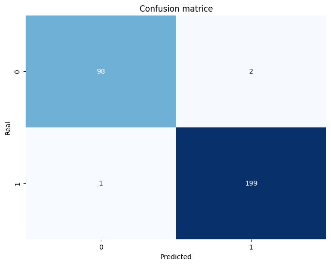

```python
plt.figure(figsize=(8, 6))
plt.title('Confusion matrice')
sns.heatmap(confusion_matrice, annot=True, fmt='d', cmap='Blues', cbar=False)
plt.xlabel('Predicted')
plt.ylabel('Real')

plt.show()
```

The results are better with this model.

Performance indicators for every threshold :

- ROC Curve: The Receiver Operating Characteristic (ROC) curve is a graph that illustrates the performance of a classification model for all classification thresholds. It plots the true positive rate (sensitivity) against the false positive rate (1-specificity).
- AUC: The Area Under the Curve (AUC) is the area beneath the ROC curve. It provides an aggregated measure of the classification model's performance across all possible classification thresholds. It can also be interpreted as the probability that a classifier will rank a randomly chosen positive example higher than a randomly chosen negative example. Values range from 0 to 1, where a value of 0.5 corresponds to a random model, and a value of 1 corresponds to a perfect model.
- ROC-AUC score: The ROC-AUC score is simply the numerical value for the AUC. It is used as a measure of the overall performance of a classification model.

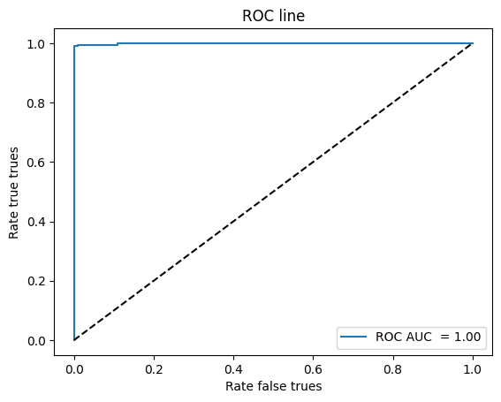

```python
#Calculate the false positive rates and true positives rates
fpr, tpr, thresholds = roc_curve(y_test, y_proba)
roc_auc = auc(fpr, tpr)

#Show ROC and AUC curve
plt.figure()
plt.title("ROC line")
plt.plot(fpr, tpr, label="ROC AUC  = %0.2f" % roc_auc)
plt.plot([0, 1], [0, 1], "k--")

plt.xlabel("Rate false trues")
plt.ylabel("Rate true trues")
plt.legend(loc="lower right")

plt.show()
```

Very high ROC AUC score -> very good global performance of the classification model

Model Selection :

In our context of fake banknote detection, where it is **crucial to detect all fake banknotes**, **Logistic Regression** seems to be the **best choice**:

## 4. Final Supervised Classification Algorithm

```python
#Looking for the best threshold
df_thresholds = pd.DataFrame((fpr,tpr, thresholds)).round(3).T

columns = ["fp rate", "tp rate", "thresholds"]
df_thresholds.columns = columns

df_thresholds
```

|  | fp rate | tp rate | thresholds |
| --- | --- | --- | --- |
| 0 | 0.00 | 0.000 | 2.000 |
| 1 | 0.00 | 0.005 | 1.000 |
| 2 | 0.00 | 0.990 | 0.756 |
| 3 | 0.01 | 0.990 | 0.644 |
| 4 | 0.01 | 0.995 | 0.614 |
| 5 | 0.11 | 0.995 | 0.077 |
| 6 | 0.11 | 1.000 | 0.069 |
| 7 | 1.00 | 1.000 | 0.000 |

The best threshold is : 0.756

- false positive rate close to 0
- true positive rate close to 1

```python
def fakebanknote_detection(csv_file, delimiter, model):
    """
    Takes a CSV file and delimiter as input,
    and returns a DataFrame with authenticity predictions for each banknote in the CSV file.

    Parameters:
    csv_file (str): The path to the CSV file. The CSV file should contain an 'id' column
                    and columns for each independent variable.
    delimiter (str): Depend of the csv file (";" , "," , " " , ".")
    model: A trained machine learning model

    Return:
    df (DataFrame): Containing the original data from the CSV file, along with an
                    'authenticity' column with authenticity predictions for each banknote
                    ('True' for authentic, 'False' for non-authentic), and a
                    'probability_authenticity' column with the associated probability for each prediction
    """
    #Read the CSV file
    X = pd.read_csv(csv_file, delimiter=delimiter)

    #Set 'id' as the index
    X.set_index('id', inplace=True)

    #Archive diagonal infomartion (useless)
    df_archive = X["diagonal"]
    X.drop("diagonal", axis=1, inplace=True)

    #Normalize the data
    norm_model = StandardScaler()
    X_scaled = norm_model.fit_transform(X)

    #Make predictions
    y_pred = model.predict(X_scaled)

    #Calculate probabilities
    probabilities = model.predict_proba(X_scaled)

    #Convert predictions to "True" or "False"
    y_pred = ['True' if pred == 1 else 'False' for pred in y_pred]

    #Add predictions to the DataFrame
    X['authenticity'] = y_pred

    #Add probabilities (%) to the DataFrame
    probabilities_true_values = probabilities[:, 1] * 100

    #Switch probabilities on 100% with best threshold
    best_threshold = 0.756 * 100
    X['probability_authenticity (%)'] =[round(prob,2) if prob >= best_threshold else (100 - round(prob,2)) for prob in probabilities_true_values]

    return X
```

```python
fakebanknote_detection(r"Ressources\billets_production.csv", ",", model_log)
```

| id | height_left | height_right | margin_low | margin_up | length | authenticity | probability_authenticity (%) |
| --- | --- | --- | --- | --- | --- | --- | --- |
| A_1 | 104.01 | 103.54 | 5.21 | 3.30 | 111.42 | False | 95.97 |
| A_2 | 104.17 | 104.13 | 6.00 | 3.31 | 112.09 | False | 98.28 |
| A_3 | 104.58 | 104.29 | 4.99 | 3.39 | 111.57 | False | 99.36 |
| A_4 | 104.55 | 104.34 | 4.44 | 3.03 | 113.20 | True | 99.99 |
| A_5 | 103.63 | 103.56 | 3.77 | 3.16 | 113.33 | True | 100.00 |